# Lab1

## 1. Framing the Problem

- This report is dedicated to find out which independent variable among, `median income`, `population`, and `number of households`, is more possible to predict the `housing price` on the `California Housing Prices Dataset`, when analizing with `Univariate Linear Regression`.

```python
# Import libraries
import os
import numpy as np
import pandas as pd
import seaborn as sns
import matplotlib.pyplot as plt
import kagglehub
from kaggle.api.kaggle_api_extended import KaggleApi
from sklearn.linear_model import LinearRegression
from sklearn import metrics
from sklearn.metrics import r2_score, mean_squared_error, mean_absolute_error
from IPython.display import display
from matplotlib.backends.backend_agg import FigureCanvasAgg as FigureCanvas
from seaborn.axisgrid import JointGrid
from IPython.display import display
from sklearn.model_selection import KFold
```

```python
# Setup environments
print(sns.__version__)
%matplotlib inline
sns.set_style("whitegrid")
```

```
0.13.2
```

## 2. Getting the Data

Data Source: Downloaded from [Kaggle California Housing Prices](https://www.kaggle.com/datasets/camnugent/california-housing-prices/data)

```python
# Authenticate
api = KaggleApi()
api.authenticate()

# Define the dataset
dataset_name = "camnugent/california-housing-prices"
download_path = "../datasets"
os.makedirs(download_path, exist_ok=True)
api.dataset_download_files(dataset_name, path=download_path, unzip=True)
print(f"Dataset downloaded to {download_path}")
```

```
Dataset URL: https://www.kaggle.com/datasets/camnugent/california-housing-prices
Dataset downloaded to ../datasets
```

Load the dataset into Pandas

```python
data_path = "../datasets/housing.csv"
housing = pd.read_csv(data_path)
print(f"Shape of dataset: {housing.shape}")
housing.head(5)
```

```
Shape of dataset: (20640, 10)
```

|  | longitude | latitude | housing_median_age | total_rooms | total_bedrooms | population | households | median_income | median_house_value | ocean_proximity |
| --- | --- | --- | --- | --- | --- | --- | --- | --- | --- | --- |
| 0 | -122.23 | 37.88 | 41.0 | 880.0 | 129.0 | 322.0 | 126.0 | 8.3252 | 452600.0 | NEAR BAY |
| 1 | -122.22 | 37.86 | 21.0 | 7099.0 | 1106.0 | 2401.0 | 1138.0 | 8.3014 | 358500.0 | NEAR BAY |
| 2 | -122.24 | 37.85 | 52.0 | 1467.0 | 190.0 | 496.0 | 177.0 | 7.2574 | 352100.0 | NEAR BAY |
| 3 | -122.25 | 37.85 | 52.0 | 1274.0 | 235.0 | 558.0 | 219.0 | 5.6431 | 341300.0 | NEAR BAY |
| 4 | -122.25 | 37.85 | 52.0 | 1627.0 | 280.0 | 565.0 | 259.0 | 3.8462 | 342200.0 | NEAR BAY |

### 3. Exploratory Data Analysis (EDA)

Get a summary of the main characteristics of the dataset.

```python
housing.describe()
```

|  | longitude | latitude | housing_median_age | total_rooms | total_bedrooms | population | households | median_income | median_house_value |
| --- | --- | --- | --- | --- | --- | --- | --- | --- | --- |
| count | 20640.000000 | 20640.000000 | 20640.000000 | 20640.000000 | 20433.000000 | 20640.000000 | 20640.000000 | 20640.000000 | 20640.000000 |
| mean | -119.569704 | 35.631861 | 28.639486 | 2635.763081 | 537.870553 | 1425.476744 | 499.539680 | 3.870671 | 206855.816909 |
| std | 2.003532 | 2.135952 | 12.585558 | 2181.615252 | 421.385070 | 1132.462122 | 382.329753 | 1.899822 | 115395.615874 |
| min | -124.350000 | 32.540000 | 1.000000 | 2.000000 | 1.000000 | 3.000000 | 1.000000 | 0.499900 | 14999.000000 |
| 25% | -121.800000 | 33.930000 | 18.000000 | 1447.750000 | 296.000000 | 787.000000 | 280.000000 | 2.563400 | 119600.000000 |
| 50% | -118.490000 | 34.260000 | 29.000000 | 2127.000000 | 435.000000 | 1166.000000 | 409.000000 | 3.534800 | 179700.000000 |
| 75% | -118.010000 | 37.710000 | 37.000000 | 3148.000000 | 647.000000 | 1725.000000 | 605.000000 | 4.743250 | 264725.000000 |
| max | -114.310000 | 41.950000 | 52.000000 | 39320.000000 | 6445.000000 | 35682.000000 | 6082.000000 | 15.000100 | 500001.000000 |

Create three Seaborn scatter plots

```python
housing.head()
```

|  | longitude | latitude | housing_median_age | total_rooms | total_bedrooms | population | households | median_income | median_house_value | ocean_proximity |
| --- | --- | --- | --- | --- | --- | --- | --- | --- | --- | --- |
| 0 | -122.23 | 37.88 | 41.0 | 880.0 | 129.0 | 322.0 | 126.0 | 8.3252 | 452600.0 | NEAR BAY |
| 1 | -122.22 | 37.86 | 21.0 | 7099.0 | 1106.0 | 2401.0 | 1138.0 | 8.3014 | 358500.0 | NEAR BAY |
| 2 | -122.24 | 37.85 | 52.0 | 1467.0 | 190.0 | 496.0 | 177.0 | 7.2574 | 352100.0 | NEAR BAY |
| 3 | -122.25 | 37.85 | 52.0 | 1274.0 | 235.0 | 558.0 | 219.0 | 5.6431 | 341300.0 | NEAR BAY |
| 4 | -122.25 | 37.85 | 52.0 | 1627.0 | 280.0 | 565.0 | 259.0 | 3.8462 | 342200.0 | NEAR BAY |

Define some dictionaries and functions to make the lab more structure.

- Dictionaries: `variables_dict`, `variables2_dict`
- Functions: `Get_mse_mae()`, `ShowJoinPlot()`

```python
# A dictionary for the three independent variables.
variables_dict = {
    "median_income": {
        "col": "median_income",
        "title": "Median House Value vs. Median Income",
        "label": "median_income",
    },
    "population": {
        "col": "population",
        "title": "Median House Value vs. Population",
        "label": "population",
    },
    "households": {
        "col": "households",
        "title": "Median House Value vs. Number of Households",
        "label": "households",
    }
}
```

```python
# A dictionary for the three model results.
variables2_dict = {
    "median_income": { # model1
        "col": "median_income",
        "predict": "m1_median_house_value",
        "GroundTruth": "median_house_value",
        "intercept": 0,
        "slope": 0,
        "mse": 0,
        "mae": 0
    },
    "population": { # model2
        "col": "population",
        "predict": "m2_median_house_value",
        "GroundTruth": "median_house_value",
        "intercept": 0,
        "slope": 0,
        "mse": 0,
        "mae": 0
    },
    "households": { # model3
        "col": "households",
        "predict": "m3_median_house_value",
        "GroundTruth": "median_house_value",
        "intercept": 0,
        "slope": 0,
        "mse": 0,
        "mae": 0
    }
}
```

```python
def Get_mse_mae(x: pd.DataFrame, y: pd.DataFrame, round_para = 2):
    mse = round(mean_squared_error(x, y), round_para)
    mae = round(mean_absolute_error(x, y), round_para)
    return mse, mae
```

```python
def ShowJoinPlot(var_dict: dict, dataset: pd.DataFrame,
                 var_dict2: dict | None = None, dataset2: pd.DataFrame | None = None):
    # Create a figure with multiple subplots in the shape of (1 row, 3 colomns)
    fig, axes = plt.subplots(1, len(var_dict), figsize=(len(var_dict) * 6, 6))

    if len(var_dict) == 1:
        axes = [axes]

    for ax, (key, value) in zip(axes, var_dict.items()):
        # Create a new figure 'jointplot' for each variable.
        g = sns.jointplot(x=value["col"], y="median_house_value", data=dataset, height=5)

        # Add second dataset if exists
        if isinstance(dataset2, pd.DataFrame):

            # For visalisation of the regression results.
            if isinstance(var_dict2, dict):
                value2 = var_dict2.get(key, None)
                if value2:
                    intercept, slope = value2["intercept"], value2["slope"]

                    """
                    Here sns.scatterplot was selected rather than plt.plot.
                    We think it sounds more sence with scatter plot since our data are discretely.
                    """
                    # plt.plot(dataset2[value2["col"]], dataset2[value2["predict"]], color='red', label='Regression Line')
                    sns.scatterplot(x=dataset2[value2["col"]], y=dataset2[value2["predict"]],
                                ax=g.ax_joint, color="brown", alpha=0.5)
                    mse = mean_squared_error(dataset2[value2["predict"]], dataset2[value2["GroundTruth"]])
                    mae = mean_absolute_error(dataset2[value2["predict"]], dataset2[value2["GroundTruth"]])

                    g.ax_joint.text(
                        0.4, 0.98, f"Intercept: {intercept:.2f}\nSlope: {slope:.2f}\nMSE: {mse:.2f}\nMAE: {mae:.2f}",
                        transform=g.ax_joint.transAxes, fontsize=12, color="brown", verticalalignment='top')

            # For visalisation when spliting dataset to train/test.
            else:
                sns.scatterplot(x=dataset2[value["col"]], y=dataset2["median_house_value"],
                            ax=g.ax_joint, color="brown", alpha=0.5)

        g.fig.suptitle(value["title"].replace(" vs. ", " vs.\n"), fontsize=14)
        g.fig.subplots_adjust(right=1, top=0.95) # adjust layout in this 'jointplot'
        # g.set_axis_labels(xlabel=value["label"].replace("_", " ").capitalize(), ylabel="Median House Value", fontsize=12)

        # Transmit the 'jointplot' figure to plt subplot.
        canvas = FigureCanvas(g.fig)
        canvas.draw()
        ax.imshow(g.fig.canvas.buffer_rgba())
        ax.set_xticks([])
        ax.set_yticks([])
        ax.set_xlabel(value["label"].replace("_", " ").capitalize(), fontsize=12)
        ax.set_ylabel("Median House Value", fontsize=12)

        # Close to avoid showing `jointplot` independently.
        plt.close(g.fig)
    plt.show()
    return
```

Draw scatter plots using the original dataset.

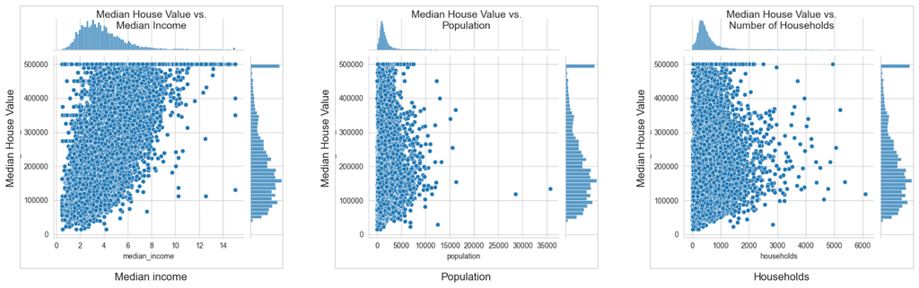

```python
ShowJoinPlot(var_dict=variables_dict, dataset=housing)
```

Some observations with the original dataset:

- Median House Value vs. Median Income:
  1. Outliers: Some outliers are exists as shown at the top of the plot.
  2. Positive correlation: Higher median income is associated with hogher house prices.
- Median House Value vs. Population:
  1. No clear correlation: There is no clear correlation between population and median house value.
  2. Smaller communities: Most of the data are closed to the lower population, this may shows that the dataset comes from smaller communities.
- Median House Value vs. Number of Households:
  1. No clear correlation: There is no clear correlation between number of households and median house value.
  2. Smaller communities: Most of the data are closed to the lower households, this may shows that the dataset comes from smaller communities.

Try to remove the outliers and draw scatter plot again.

```
After filtering, there are 19648 records, versus 20640 before filtering
```

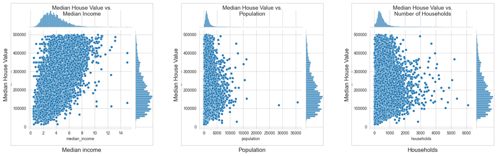

```python
# After filtering, there are 19675 records, versus 20640 before filtering
housing_preprocessed = housing[housing.median_house_value < 500000]
# After filtering, there are 19648 records, versus 20640 before filtering
print(f"After filtering, there are {len(housing_preprocessed)} records, versus {len(housing)} before filtering")
ShowJoinPlot(var_dict=variables_dict, dataset=housing_preprocessed)
```

Some observations after filtering (remove outliers of `median_house_value > 500000`):

- The distribution of the `median house value` becomes more similar to the shape of normal distribution.

More statistic results of these 4 variables (original dataset).

```python
housing[["median_house_value", "median_income", "population", "households"]].describe()
```

|  | median_house_value | median_income | population | households |
| --- | --- | --- | --- | --- |
| count | 20640.000000 | 20640.000000 | 20640.000000 | 20640.000000 |
| mean | 206855.816909 | 3.870671 | 1425.476744 | 499.539680 |
| std | 115395.615874 | 1.899822 | 1132.462122 | 382.329753 |
| min | 14999.000000 | 0.499900 | 3.000000 | 1.000000 |
| 25% | 119600.000000 | 2.563400 | 787.000000 | 280.000000 |
| 50% | 179700.000000 | 3.534800 | 1166.000000 | 409.000000 |
| 75% | 264725.000000 | 4.743250 | 1725.000000 | 605.000000 |
| max | 500001.000000 | 15.000100 | 35682.000000 | 6082.000000 |

More statistic results of these 4 variables (filtered dataset).

```python
# (remove outliers of `median_house_value > 500000`)
housing_preprocessed[["median_house_value", "median_income", "population", "households"]].describe()
```

|  | median_house_value | median_income | population | households |
| --- | --- | --- | --- | --- |
| count | 19648.000000 | 19648.000000 | 19648.000000 | 19648.000000 |
| mean | 192055.328583 | 3.676411 | 1441.368485 | 501.192488 |
| std | 97110.854998 | 1.570602 | 1144.075196 | 383.391367 |
| min | 14999.000000 | 0.499900 | 3.000000 | 2.000000 |
| 25% | 116475.000000 | 2.526300 | 796.000000 | 282.000000 |
| 50% | 173600.000000 | 3.449050 | 1179.000000 | 411.000000 |
| 75% | 247900.000000 | 4.582500 | 1746.250000 | 606.000000 |
| max | 499100.000000 | 15.000100 | 35682.000000 | 6082.000000 |

```python
print(f"std housing: {housing["median_house_value"].std()}")
print(f"std housing_preprocessed: {housing_preprocessed["median_house_value"].std()}")
rate = round(((housing_preprocessed["median_house_value"].std() - housing["median_house_value"].std()) / housing["median_house_value"].std()), 2)*100
print(f"The std of house price reduced {0-rate}% after filtering.")
```

```
std housing: 115395.61587441387
std housing_preprocessed: 97110.85499789551
The std of house price reduced 16.0% after filtering.
```

### Observation:

#### About the 4 variables:

1. median_house_value:  
   The median house value for homes in a block (in US Dollars).  
   This is the dependent variable we want to predict in this report.
2. median income:  
   The median income of families in a block (in tens of thousands of US Dollars). Based on the review of scatter plot, this variable may be a strong predictor of house prices, since it has a clear positive correlation of the price.
3. population:  
   The total number of people living in a block. Based on the review of scatter plot, this could be a weak predictor, since there are no clear relationships with the price.
4. number of households:  
   The total number of home units in a block. Based on the review of scatter plot, this could also be a weak predictor, since there are no clear correlation with the price.

#### Filtering:

- Removing outliers can be important:  
  The std of house price reduced 16.0% after filtering.

### 4. Run three linear regressions (fitting) between:

median house value vs. median income median house value vs. population median house value vs. number of households.

Splitting dataset for training and testing.

- Training set: contains 80% of the filtered data.
- Testing set: contains 20% of the filtered data.

Visualize our dataset (Blue: training set; Brown: testing set)

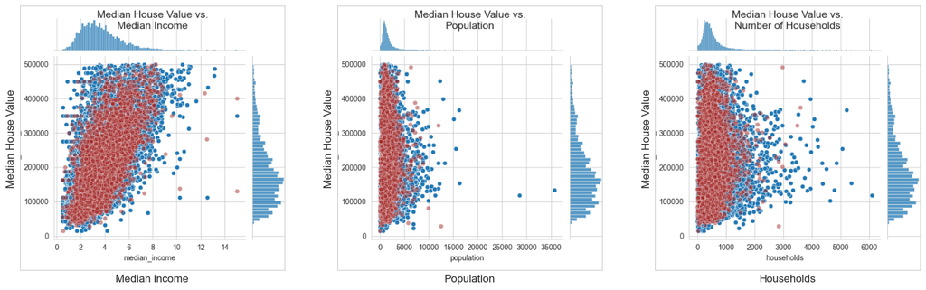

```python
# Visualize our dataset
train_size = int(len(housing_preprocessed) * 0.8)
train = housing_preprocessed[:train_size]
test = housing_preprocessed[train_size:]
ShowJoinPlot(var_dict=variables_dict, dataset=train, dataset2=test)
```

### Cross validation:

- We define a function `Gen_cross_valid_dataset()` to generate `5` cross dataset with different training/testing split.
- The cross validation data are stored in `df_cross_data`.

```python
def Gen_cross_valid_dataset(datain : pd.DataFrame, n=5):
    kf = KFold(n_splits=5, shuffle=True, random_state=42)
    _cross_data = []
    for i, (train_idx, test_idx) in enumerate(kf.split(datain)):
        train, test = datain.iloc[train_idx], datain.iloc[test_idx]
        _cross_data.append({"train": train, "test": test})
        print(f"Fold {i + 1}: Train size = {len(train)}, Test size = {len(test)}")
    _df_cross_data = pd.DataFrame.from_records(_cross_data)
    return _df_cross_data
```

```python
df_cross_data = Gen_cross_valid_dataset(datain=housing_preprocessed, n=5)
```

```
Fold 1: Train size = 15718, Test size = 3930
Fold 2: Train size = 15718, Test size = 3930
Fold 3: Train size = 15718, Test size = 3930
Fold 4: Train size = 15719, Test size = 3929
Fold 5: Train size = 15719, Test size = 3929
```

Visualize the data for each cross-validaiton dataset. (Blue: training set; Brown: testing set)

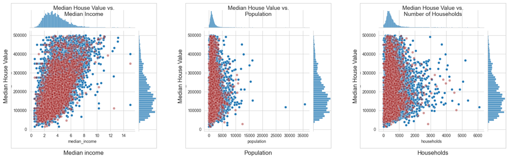

```python
# Plot for all folders
for k in range(df_cross_data.shape[0]):
    train_k = df_cross_data["train"].iloc[k]
    test_k = df_cross_data["test"].iloc[k]

    if k == 0: # We only plot for the first folder (There are no big differents among the folds.)
        ShowJoinPlot(var_dict=variables_dict, dataset=train_k, dataset2=test_k)
```

### Ready for the Linear regressions.

We will run and anlysis these modes in the following for loop.

Each model will be run 5 times:

- Model 1 (Linear regressions: median house value vs. median income)
- Model 2 (Linear regressions: median house value vs. population)
- Model 3 (Linear regressions: median house value vs. numbers of households)

Each time we will collecte the intercept, slope, MSE and MAE.

- Calculate the mse and mae with the predicted values from training and testing set.
- Store the results into `df_model_result_trainset` and `variables2_dict`.

```
Scatter plot for the training set will shown bellow.
```

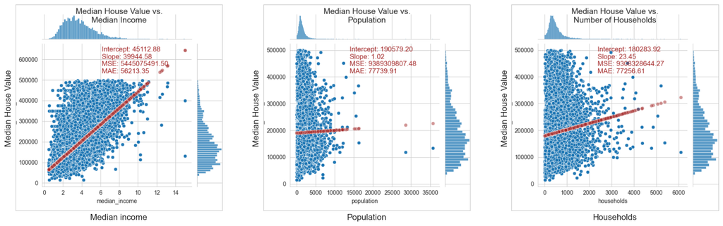

```
Scatter plot for the testing set will shown bellow.
```

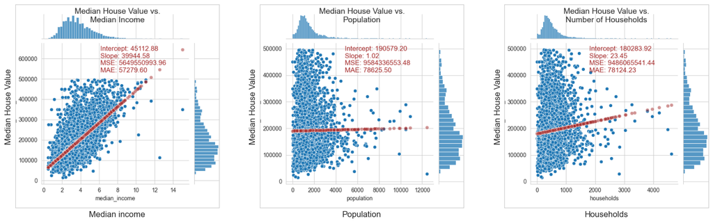

```python
regression_results_list = []
# Linear regression
for k in range(df_cross_data.shape[0]):
    train_k = df_cross_data["train"].iloc[k]
    test_k = df_cross_data["test"].iloc[k]

    # Create dataframes for storing results
    _df_model_result_trainset = pd.DataFrame()
    _df_model_result_testset = pd.DataFrame()
    _variables2_dict = variables2_dict

    # Storing the ground truth
    _df_model_result_trainset["median_house_value"] = train_k["median_house_value"]
    _df_model_result_testset["median_house_value"] = test_k["median_house_value"]

    """
    Model 1
        Running linear regression by "median_income" and "median_house_value".
    """
    # Train and predict
    _model1 = LinearRegression()
    _model1.fit(X=train_k[["median_income"]], y=train_k[["median_house_value"]])
    _df_model_result_trainset["median_income"] = train_k[["median_income"]]
    _df_model_result_trainset["m1_median_house_value"] = _model1.predict(train_k[["median_income"]])
    _df_model_result_testset["median_income"] = test_k[["median_income"]]
    _df_model_result_testset["m1_median_house_value"] = _model1.predict(test_k[["median_income"]])

    # Collect the intercept, slope, MSE and MAE.
    _model1_intercept, _model1_slope = round(_model1.intercept_[0], 2), round(_model1.coef_[0][0], 2)
    _variables2_dict["median_income"]["intercept"] = _model1_intercept
    _variables2_dict["median_income"]["slope"] = _model1_slope
    _tr_m1_mse, _tr_m1_mae = Get_mse_mae(
        x=_df_model_result_trainset["m1_median_house_value"],
        y=_df_model_result_trainset["median_house_value"])
    _te_m1_mse, _te_m1_mae = Get_mse_mae(
        x=_df_model_result_testset["m1_median_house_value"],
        y=_df_model_result_testset["median_house_value"])

    """
    Model 2
        Running linear regression by "population" and "median_house_value".
    """
    # Train and predict
    _model2 = LinearRegression()
    _model2.fit(X=train_k[["population"]], y=train_k[["median_house_value"]])
    _df_model_result_trainset["population"] = train_k[["population"]]
    _df_model_result_trainset["m2_median_house_value"] = _model2.predict(train_k[["population"]])
    _df_model_result_testset["population"] = test_k[["population"]]
    _df_model_result_testset["m2_median_house_value"] = _model2.predict(test_k[["population"]])

    # Collect the intercept, slope, MSE and MAE.
    _model2_intercept, _model2_slope = round(_model2.intercept_[0], 2), round(_model2.coef_[0][0], 2)
    _variables2_dict["population"]["intercept"] = _model2_intercept
    _variables2_dict["population"]["slope"] = _model2_slope

    _tr_m2_mse, _tr_m2_mae = Get_mse_mae(
        x=_df_model_result_trainset["m2_median_house_value"],
        y=_df_model_result_trainset["median_house_value"])
    _te_m2_mse, _te_m2_mae = Get_mse_mae(
        x=_df_model_result_testset["m2_median_house_value"],
        y=_df_model_result_testset["median_house_value"])

    """
    Model 3
        Running linear regression by "households" and "median_house_value".
        Calculate the mse and mae with the predicted values from training and testing set.

        Store the results into 'df_model_result_trainset' and 'variables2_dict'.
    """
    # Train and predict
    _model3 = LinearRegression()
    _model3.fit(X=train_k[["households"]], y=train_k[["median_house_value"]])
    _df_model_result_trainset["households"] = train_k[["households"]]
    _df_model_result_trainset["m3_median_house_value"] = _model3.predict(train_k[["households"]])
    _df_model_result_testset["households"] = test_k[["households"]]
    _df_model_result_testset["m3_median_house_value"] = _model3.predict(test_k[["households"]])

    # Collect the intercept, slope, MSE and MAE.
    _model3_intercept, _model3_slope = round(_model3.intercept_[0], 2), round(_model3.coef_[0][0], 2)
    _variables2_dict["households"]["intercept"] = _model3_intercept
    _variables2_dict["households"]["slope"] = _model3_slope

    _tr_m3_mse, _tr_m3_mae = Get_mse_mae(
        x=_df_model_result_trainset["m3_median_house_value"],
        y=_df_model_result_trainset["median_house_value"])
    _te_m3_mse, _te_m3_mae = Get_mse_mae(
        x=_df_model_result_testset["m3_median_house_value"],
        y=_df_model_result_testset["median_house_value"])

    # Collecte and keep them in _df_regression_result
    _df_regression_result = pd.DataFrame({
        "Model": ["Model1_median_income", "Model2_population", "Model3_households"],
        "Intercept": [_model1_intercept, _model2_intercept, _model3_intercept],
        "Slope": [_model1_slope, _model2_slope, _model3_slope],
        "MSE_trainset": [_tr_m1_mse, _tr_m2_mse, _tr_m3_mse],
        "MAE_trainset": [_tr_m1_mae, _tr_m2_mae, _tr_m2_mae],
        "MSE_testset": [_te_m1_mse, _te_m2_mse, _te_m3_mse],
        "MAE_testset": [_te_m1_mae, _te_m2_mae, _te_m3_mae]
    })
    regression_results_list.append(_df_regression_result)

    # Plot
    if k == 0:  # We only plot for the first folder.
        print("Scatter plot for the training set will shown bellow.")
        ShowJoinPlot(var_dict=variables_dict, dataset=train_k, var_dict2=_variables2_dict, dataset2=_df_model_result_trainset)
        print("\nScatter plot for the testing set will shown bellow.")
        ShowJoinPlot(var_dict=variables_dict, dataset=test_k, var_dict2=_variables2_dict, dataset2=_df_model_result_testset)


df_regression_results = pd.concat(regression_results_list, ignore_index=True)
```

### 5. In a single table for all three linear regressions, provide per regression model:

- We run each model five times with different cross-valided folders.  
  (Model 1 (median_income), Model 2 (population), Model 3 (households))
- Totally there are 15 rows of analysis data shown as bellow (stored in `df_regression_results`).

```python
display(df_regression_results)
```

[output not shown]

For each model, we compute the average, as shown bellow.

```python
def compute_averages(df: pd.DataFrame):
    cols_to_avg = ["Intercept", "Slope", "MSE_trainset", "MAE_trainset", "MSE_testset", "MAE_testset"]
    df_avg = df.groupby("Model")[cols_to_avg].mean().round(2).reset_index()
    return df_avg

df_model_averages = compute_averages(df_regression_results)
display(df_model_averages)
```

|  | Model | Intercept | Slope | MSE_trainset | MAE_trainset | MSE_testset | MAE_testset |
| --- | --- | --- | --- | --- | --- | --- | --- |
| 0 | Model1_median_income | 45047.32 | 39986.83 | 5.485841e+09 | 56436.94 | 5.487031e+09 | 56444.25 |
| 1 | Model2_population | 190390.11 | 1.15 | 9.428004e+09 | 77917.12 | 9.430933e+09 | 77928.61 |
| 2 | Model3_households | 179915.06 | 24.22 | 9.343636e+09 | 77917.12 | 9.345179e+09 | 77432.77 |

### 6. Summary

1. Based on the results, model1 which is trained by median_income has the lowest mse and mae error compared to other models. It was related to the observation by the scatterplot.
2. However, in this case liniear regression approach is still not good enough to predict the housing price. Since our dataset are located in such a nonlinear way, I think is impossible to predict by using linear approach, maybe some other non-linear methods will be better.